# newmetandunmet

```python
import warnings
```

```python
warnings.filterwarnings('ignore')
```

```python
import pandas as pd
import numpy as np
import seaborn as sns
import matplotlib.pyplot as plt
```

```python
df=pd.read_csv(r'C:\Users\DAMMY\Desktop\prop_data.csv')
pd.set_option('display.max_columns', None)
df
```

|  | AGE | GENDER | HIGHEST_EDUCATION | LIVING_ARRANGEMENT | MARITAL_STATUS | OCCUPATION | YEARS_OF_RESIDENCE | HOUSING_TYPE | WATER_SOURCE | SEWAGE_DISPOSAL | HEALTHCARE_FACILITY_ACCESSIBILITY | HEALTHCARE_FACILITY_DISTANCE | EXERCISE_PRACTICED | HOSPITALIZATION | PRIMARY_HEALTHCARE_PROVIDER | MONITORS_AT_HOME | THE_PRIMARY_HEALTHCARE_PROVIDER | VISIT_PRIMARY_HEALTHCARE_PROVIDER | UNORTHODOX_HEALTHCARE | UNORTHODOX_PATRONAGE | BLOOD_PRESSURE_CHECK | DENTAL_CHECK | EYE_CHECK | Specialist_Cancer_24a | Specialist_Skin_Doctor_24b | Specialist_Kidney_Doctor_24c | Specialist_Heart_Doctor_24d | Specialist_Eye_Doctor_24e | Specialist_Others_24g | … |
| --- | --- | --- | --- | --- | --- | --- | --- | --- | --- | --- | --- | --- | --- | --- | --- | --- | --- | --- | --- | --- | --- | --- | --- | --- | --- | --- | --- | --- | --- | --- |
| 0 | 66 and above | Male | Primary | Alone | Married | Trader | 5 | Rented | Sanitary well | Sanitary latrine | Very difficult | Less than 1 km | 4 | 1 | 2 | 2 | 0 | 0 | 1 | 3 | 2 | 0 | 0 | 0 | 0 | 0 | 0 | 0 | 0 | … |
| 1 | 66 and above | Female | No formal education | Alone | Widow | Trader | 5 | Rented | Rainwater | Sanitary latrine | Very easy | 1-5 km | 4 | 1 | 2 | 2 | 0 | 0 | 1 | 1 | 0 | 0 | 0 | 0 | 0 | 0 | 0 | 0 | 0 | … |
| 2 | 60 and above | Female | Secondary | Alone | Married | Trader | 4 | Rented | Sanitary well | Sanitary latrine | Difficult | Less than 1 km | 4 | 1 | 2 | 2 | 0 | 0 | 1 | 3 | 0 | 0 | 0 | 0 | 0 | 0 | 0 | 0 | 0 | … |
| 3 | 70 and above | Male | Primary | Alone | Married | Trader | 6 | Owned | Sanitary well | Sanitary latrine | Very easy | 1-5 km | 4 | 1 | 1 | 2 | 1 | 3 | 1 | 3 | 1 | 4 | 4 | 0 | 0 | 0 | 0 | 1 | 0 | … |
| 4 | 66 and above | Female | Primary | Alone | Married | Trader | 2 | Rented | Sanitary well | Sanitary latrine | Difficult | Within a few meters of walking distance | 4 | 2 | 1 | 1 | 2 | 3 | 0 | 0 | 2 | 0 | 0 | 0 | 0 | 0 | 0 | 0 | 0 | … |
| ... | ... | ... | ... | ... | ... | ... | ... | ... | ... | ... | ... | ... | ... | ... | ... | ... | ... | ... | ... | ... | ... | ... | ... | ... | ... | ... | ... | ... | ... | … |
| 395 | 60 and above | Female | Primary | Alone | Married | Trader | 7 | Owned | Borehole | Sanitary latrine | Very easy | 1-5 km | 4 | 1 | 1 | 2 | 1 | 2 | 1 | 1 | 2 | 5 | 1 | 0 | 0 | 0 | 0 | 1 | 0 | … |
| 396 | 80-120 | Female | Primary | Alone | Widow | Trader | 7 | Owned | Borehole | Sanitary latrine | Very easy | 1-5 km | 4 | 2 | 1 | 1 | 1 | 2 | 1 | 1 | 2 | 4 | 3 | 0 | 0 | 0 | 0 | 1 | 0 | … |
| 397 | 70 and above | Female | No formal education | Alone | Divorced | Artisan | 4 | Rented | Borehole | Sanitary latrine | Very easy | 1-5 km | 4 | 1 | 1 | 2 | 1 | 3 | 0 | 0 | 0 | 0 | 0 | 0 | 0 | 0 | 0 | 0 | 0 | … |
| 398 | 60 and above | Female | Secondary | Alone | Widow | Trader | 4 | Rented | Sanitary well | Sanitary latrine | Very easy | Less than 1 km | 4 | 2 | 2 | 2 | 0 | 0 | 0 | 0 | 5 | 0 | 0 | 0 | 0 | 0 | 0 | 0 | 0 | … |
| 399 | 70 and above | Male | No formal education | Alone | Single | Artisan | 4 | Rented | Sanitary well | Sanitary latrine | Very easy | 1-5 km | 4 | 1 | 1 | 2 | 1 | 4 | 1 | 1 | 1 | 0 | 0 | 0 | 0 | 0 | 0 | 0 | 0 | … |

400 rows × 66 columns

```python
df.info()
```

```
<class 'pandas.core.frame.DataFrame'>
RangeIndex: 400 entries, 0 to 399
Data columns (total 66 columns):
 #   Column                             Non-Null Count  Dtype
---  ------                             --------------  -----
 0   AGE                                400 non-null    object
 1   GENDER                             400 non-null    object
 2   HIGHEST_EDUCATION                  400 non-null    object
 3   LIVING_ARRANGEMENT                 400 non-null    object
 4   MARITAL_STATUS                     400 non-null    object
 5   OCCUPATION                         400 non-null    object
 6   YEARS_OF_RESIDENCE                 400 non-null    int64
 7   HOUSING_TYPE                       400 non-null    object
 8   WATER_SOURCE                       400 non-null    object
 9   SEWAGE_DISPOSAL                    400 non-null    object
```

[output cut: 58 more lines]

```python
df.describe()
```

|  | YEARS_OF_RESIDENCE | EXERCISE_PRACTICED | HOSPITALIZATION | PRIMARY_HEALTHCARE_PROVIDER | MONITORS_AT_HOME | THE_PRIMARY_HEALTHCARE_PROVIDER | VISIT_PRIMARY_HEALTHCARE_PROVIDER | UNORTHODOX_HEALTHCARE | UNORTHODOX_PATRONAGE | BLOOD_PRESSURE_CHECK | DENTAL_CHECK | EYE_CHECK | Specialist_Cancer_24a | Specialist_Skin_Doctor_24b | Specialist_Kidney_Doctor_24c | Specialist_Heart_Doctor_24d | Specialist_Eye_Doctor_24e | SATISFICATION_WITH_THE_SPECIALIST | PSYCHOLOGICAL_SUPPORT | HEALTHCARE_NEEDS_MET | INAPPROPRIATE_PRIORITY_OF_ELDERS | HEALTHCARE_SERVICES_SOUGHT |
| --- | --- | --- | --- | --- | --- | --- | --- | --- | --- | --- | --- | --- | --- | --- | --- | --- | --- | --- | --- | --- | --- | --- |
| count | 400.000000 | 400.000000 | 400.000000 | 400.000000 | 400.000000 | 400.00000 | 400.000000 | 400.00000 | 400.000000 | 400.000000 | 400.000000 | 400.000000 | 400.000000 | 400.000000 | 400.000000 | 400.000000 | 400.000000 | 400.000000 | 400.000000 | 400.000000 | 400.000000 | 400.000000 |
| mean | 4.785000 | 3.935000 | 1.352500 | 1.455000 | 1.880000 | 0.88500 | 1.560000 | 1.09750 | 1.572500 | 2.987500 | 1.617500 | 1.980000 | 0.020000 | 0.022500 | 0.040000 | 0.120000 | 0.537500 | 0.862500 | 0.035000 | 6.625000 | 2.220000 | 1.057500 |
| std | 1.646375 | 0.246835 | 0.478347 | 0.498595 | 0.325369 | 0.91041 | 1.463473 | 0.78392 | 0.917523 | 1.816754 | 2.218897 | 2.156671 | 0.140175 | 0.148489 | 0.196205 | 0.325369 | 0.806362 | 0.916894 | 0.262578 | 1.025673 | 1.413008 | 0.771805 |
| min | 1.000000 | 3.000000 | 1.000000 | 1.000000 | 1.000000 | 0.00000 | 0.000000 | 0.00000 | 0.000000 | 0.000000 | 0.000000 | 0.000000 | 0.000000 | 0.000000 | 0.000000 | 0.000000 | 0.000000 | 0.000000 | 0.000000 | 4.000000 | 1.000000 | 0.000000 |
| 25% | 4.000000 | 4.000000 | 1.000000 | 1.000000 | 2.000000 | 0.00000 | 0.000000 | 1.00000 | 1.000000 | 2.000000 | 0.000000 | 0.000000 | 0.000000 | 0.000000 | 0.000000 | 0.000000 | 0.000000 | 0.000000 | 0.000000 | 6.000000 | 1.000000 | 1.000000 |
| 50% | 5.000000 | 4.000000 | 1.000000 | 1.000000 | 2.000000 | 1.00000 | 2.000000 | 1.00000 | 1.000000 | 2.000000 | 0.000000 | 0.000000 | 0.000000 | 0.000000 | 0.000000 | 0.000000 | 0.000000 | 1.000000 | 0.000000 | 7.000000 | 1.000000 | 1.000000 |
| 75% | 6.000000 | 4.000000 | 2.000000 | 2.000000 | 2.000000 | 1.00000 | 3.000000 | 1.00000 | 2.000000 | 5.000000 | 4.000000 | 4.000000 | 0.000000 | 0.000000 | 0.000000 | 0.000000 | 1.000000 | 2.000000 | 0.000000 | 7.000000 | 4.000000 | 1.000000 |
| max | 8.000000 | 4.000000 | 2.000000 | 2.000000 | 2.000000 | 4.00000 | 4.000000 | 5.00000 | 3.000000 | 5.000000 | 5.000000 | 5.000000 | 1.000000 | 1.000000 | 1.000000 | 1.000000 | 5.000000 | 2.000000 | 2.000000 | 9.000000 | 6.000000 | 5.000000 |

```python
df.isnull().sum()
```

```
AGE                         0
GENDER                      0
HIGHEST_EDUCATION           0
LIVING_ARRANGEMENT          0
MARITAL_STATUS              0
                           ..
Disease_Dental_34e          0
Disease_Diabetes_34f        0
Disease_Hypertension_34g    0
Disease_Others              0
REPUTABLE_PHARMACIES        0
Length: 66, dtype: int64
```

```python
health_related_columns = ["AGE",
    "EXERCISE_PRACTICED",
    "HOSPITALIZATION",
    "PRIMARY_HEALTHCARE_PROVIDER",
    "MONITORS_AT_HOME",
    "THE_PRIMARY_HEALTHCARE_PROVIDER",
    "VISIT_PRIMARY_HEALTHCARE_PROVIDER",
    "UNORTHODOX_HEALTHCARE",
    "UNORTHODOX_PATRONAGE",
    "BLOOD_PRESSURE_CHECK",
    "DENTAL_CHECK",
    "EYE_CHECK",
    "Specialist_Cancer_24a",
    "Specialist_Skin_Doctor_24b",
    "Specialist_Kidney_Doctor_24c",
    "Specialist_Heart_Doctor_24d",
    "Specialist_Eye_Doctor_24e",
    "Specialist_Others_24g",
    "SATISFICATION_WITH_THE_SPECIALIST",
    "PSYCHOLOGICAL_SUPPORT",
    "HEALTHCARE_NEEDS_MET",
    "INAPPROPRIATE_PRIORITY_OF_ELDERS",
    "HEALTHCARE_SERVICES_SOUGHT",
    "Availability_Preventive_33b",
    "Availability_Caregiver_33c",
    "Availability_Mental_Support_33d",
    "Availability_Pain_Management_33e",
    "Availability_Chronic_Dx_33f",
    "Availability_Others_33g",
    "Disease_Arthritis_34a",
    "Disease_Eye_34b",
    "Disease_Dementia_34c",
    "Disease_Ear_34d",
    "Disease_Dental_34e",
    "Disease_Diabetes_34f",
    "Disease_Hypertension_34g",
    "Disease_Others",
    "REPUTABLE_PHARMACIES"
]

for column in health_related_columns:
    value_counts = df[column].value_counts()
    total_values = len(df[column])
    percentages = (value_counts / total_values) * 100
    print(f"Column: {column}")
    print(pd.concat([value_counts, percentages], axis=1, keys=['Counts', 'Percentages']))
    print("-" * 50)
```

```
Column: AGE
              Counts  Percentages
66 and above     169        42.25
60 and above     109        27.25
70 and above      72        18.00
80-120            50        12.50
--------------------------------------------------
Column: EXERCISE_PRACTICED
   Counts  Percentages
4     374         93.5
3      26          6.5
--------------------------------------------------
Column: HOSPITALIZATION
   Counts  Percentages
1     259        64.75
2     141        35.25
--------------------------------------------------
Column: PRIMARY_HEALTHCARE_PROVIDER
   Counts  Percentages
1     218         54.5
2     182         45.5
--------------------------------------------------
Column: MONITORS_AT_HOME
   Counts  Percentages
2     352         88.0
1      48         12.0
--------------------------------------------------
Column: THE_PRIMARY_HEALTHCARE_PROVIDER
   Counts  Percentages
1     179        44.75
0     150        37.50
2      46        11.50
3      17         4.25
4       8         2.00
--------------------------------------------------
Column: VISIT_PRIMARY_HEALTHCARE_PROVIDER
   Counts  Percentages
0     166        41.50
2     107        26.75
3      71        17.75
```

[output cut: 167 more lines]

```
--------------------------------------------------
Column: Disease_Hypertension_34g
     Counts  Percentages
No      210         52.5
Yes     190         47.5
--------------------------------------------------
Column: Disease_Others
    Counts  Percentages
No     400        100.0
--------------------------------------------------
Column: REPUTABLE_PHARMACIES
     Counts  Percentages
Yes     398         99.5
No        2          0.5
--------------------------------------------------
```

### Objective 1: To identify the common health-related problems prevalent among the ageing residents of Mushin local government area of Lagos State.

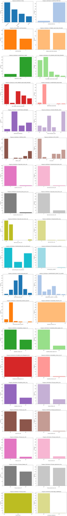

```python
# Define the number of columns per row
columns_per_row = 2

# Calculate the number of rows needed
num_columns = len(health_related_columns)
num_rows = int(np.ceil(num_columns / columns_per_row))

# Define a list of beautiful colors for the charts
chart_colors = plt.cm.tab20.colors

# Create subplots with the desired layout
fig, axs = plt.subplots(num_rows, columns_per_row, figsize=(15, 6 * num_rows))

# Flatten the axs array if it's a single row
if num_rows == 1:
    axs = [axs]

# Plot each health-related column
for i, column in enumerate(health_related_columns):
    row = i // columns_per_row
    col = i % columns_per_row

    value_counts = df[column].value_counts()

    ax = axs[row, col]
    ax.bar(value_counts.index, value_counts.values, color=chart_colors[i % len(chart_colors)])
    ax.set_xlabel(column)
    ax.set_ylabel("Frequency")
    ax.set_title(f"Frequency Distribution of {column}")
    ax.tick_params(axis="x", rotation=45)
    ax.xaxis.set_major_locator(plt.MaxNLocator(len(value_counts.index)))  # Avoid crowded x-axis labels

    if i == num_columns - 1 and num_columns % columns_per_row != 0:
        axs[row, col + 1].axis("off")  # Turn off the empty subplot in the last row if needed

plt.tight_layout()
plt.show()
```

### Objective 2: To identify and assess the healthcare needs of the ageing residents in Mushin local government area of Lagos State

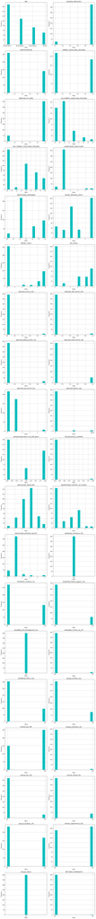

```
       EXERCISE_PRACTICED  HOSPITALIZATION  PRIMARY_HEALTHCARE_PROVIDER  \
count          400.000000       400.000000                   400.000000
mean             3.935000         1.352500                     1.455000
std              0.246835         0.478347                     0.498595
min              3.000000         1.000000                     1.000000
25%              4.000000         1.000000                     1.000000
50%              4.000000         1.000000                     1.000000
75%              4.000000         2.000000                     2.000000
max              4.000000         2.000000                     2.000000

       MONITORS_AT_HOME  THE_PRIMARY_HEALTHCARE_PROVIDER  \
count        400.000000                        400.00000
mean           1.880000                          0.88500
std            0.325369                          0.91041
min            1.000000                          0.00000
25%            2.000000                          0.00000
50%            2.000000                          1.00000
75%            2.000000                          1.00000
max            2.000000                          4.00000

       VISIT_PRIMARY_HEALTHCARE_PROVIDER  UNORTHODOX_HEALTHCARE  \
count                         400.000000              400.00000
mean                            1.560000                1.09750
std                             1.463473                0.78392
min                             0.000000                0.00000
25%                             0.000000                1.00000
50%                             2.000000                1.00000
75%                             3.000000                1.00000
max                             4.000000                5.00000

       UNORTHODOX_PATRONAGE  BLOOD_PRESSURE_CHECK  DENTAL_CHECK   EYE_CHECK  \
count            400.000000            400.000000    400.000000  400.000000
mean               1.572500              2.987500      1.617500    1.980000
std                0.917523              1.816754      2.218897    2.156671
min                0.000000              0.000000      0.000000    0.000000
25%                1.000000              2.000000      0.000000    0.000000
50%                1.000000              2.000000      0.000000    0.000000
75%                2.000000              5.000000      4.000000    4.000000
max                3.000000              5.000000      5.000000    5.000000

```

[output cut: 34 more lines]

```
min                 0.000000              4.000000
25%                 0.000000              6.000000
50%                 0.000000              7.000000
75%                 0.000000              7.000000
max                 2.000000              9.000000

       INAPPROPRIATE_PRIORITY_OF_ELDERS  HEALTHCARE_SERVICES_SOUGHT
count                        400.000000                  400.000000
mean                           2.220000                    1.057500
std                            1.413008                    0.771805
min                            1.000000                    0.000000
25%                            1.000000                    1.000000
50%                            1.000000                    1.000000
75%                            4.000000                    1.000000
max                            6.000000                    5.000000
```

```python
import pandas as pd
import matplotlib.pyplot as plt

# Define the columns related to healthcare needs
healthcare_needs = ["AGE",
    "EXERCISE_PRACTICED",
    "HOSPITALIZATION",
    "PRIMARY_HEALTHCARE_PROVIDER",
    "MONITORS_AT_HOME",
    "THE_PRIMARY_HEALTHCARE_PROVIDER",
    "VISIT_PRIMARY_HEALTHCARE_PROVIDER",
    "UNORTHODOX_HEALTHCARE",
    "UNORTHODOX_PATRONAGE",
    "BLOOD_PRESSURE_CHECK",
    "DENTAL_CHECK",
    "EYE_CHECK",
    "Specialist_Cancer_24a",
    "Specialist_Skin_Doctor_24b",
    "Specialist_Kidney_Doctor_24c",
    "Specialist_Heart_Doctor_24d",
    "Specialist_Eye_Doctor_24e",
    "Specialist_Others_24g",
    "SATISFICATION_WITH_THE_SPECIALIST",
    "PSYCHOLOGICAL_SUPPORT",
    "HEALTHCARE_NEEDS_MET",
    "INAPPROPRIATE_PRIORITY_OF_ELDERS",
    "HEALTHCARE_SERVICES_SOUGHT",
    "Availability_Preventive_33b",
    "Availability_Caregiver_33c",
    "Availability_Mental_Support_33d",
    "Availability_Pain_Management_33e",
    "Availability_Chronic_Dx_33f",
    "Availability_Others_33g",
    "Disease_Arthritis_34a",
    "Disease_Eye_34b",
    "Disease_Dementia_34c",
    "Disease_Ear_34d",
    "Disease_Dental_34e",
    "Disease_Diabetes_34f",
    "Disease_Hypertension_34g",
    "Disease_Others",
    "REPUTABLE_PHARMACIES"
]

# Create a DataFrame containing only the healthcare needs columns
healthcare_needs_df = df[healthcare_needs]

# Calculate descriptive statistics (mean, median, std)
descriptive_stats = healthcare_needs_df.describe()
descriptive_stats_table = descriptive_stats.to_html()

# Visualize using histograms
num_columns = len(healthcare_needs)
num_rows = int(num_columns / 2) + (num_columns % 2)  # Calculate the number of rows needed

fig, axs = plt.subplots(num_rows, 2, figsize=(12, 6 * num_rows))
axs = axs.flatten()

for i, column in enumerate(healthcare_needs):
    ax = axs[i]
    healthcare_needs_df[column].hist(ax=ax, color='c', bins=15)
    ax.set_title(column)
    ax.set_xlabel("Value")
    ax.set_ylabel("Frequency")

# Turn off empty subplots if present
if num_columns % 2 != 0:
    axs[-1].axis("off")

plt.tight_layout()
plt.show()

print(descriptive_stats)
```

#### Observations:

##### - 'HEALTHCARE_NEEDS_MET' appears to have a higher frequency in certain categories.

##### - The 'SATISFICATION_WITH_THE_SPECIALIST' column shows variation in satisfaction levels.

##### - The presence of health conditions like 'Disease_Arthritis_34a' and 'Disease_Diabetes_34f' is evident.

### Objective 3: To identify the facilitators and barriers to healthcare utilization among the ageing residents in Mushin local government area of Lagos State.

```python
barrier = [
    "Barrier_Transport_30a",
    "Barrier_Appointment_30b",
    "Barrier_Mobility_30c",
    "Barrier_Language_30d",
    "Barrier_Financial_30e",
    "Barrier_Waiting_Time_30f",
    "Barrier_InhospitableStaff_30g",
    "Barrier_Others_30h"
]
```

```python
facilitator = [
    "Availability_Preventive_33b",
    "Availability_Caregiver_33c",
    "Availability_Mental_Support_33d",
    "Availability_Pain_Management_33e"
]
```

```python
# Count the frequency of each barrier
barrier_counts = df[barrier].apply(pd.Series.value_counts)

# Count the frequency of each facilitator
facilitator_counts = df[facilitator].apply(pd.Series.value_counts)

# Print the frequency counts
print("Barrier Frequency Counts:")
print(barrier_counts)

print("\nFacilitator Frequency Counts:")
print(facilitator_counts)
```

```
Barrier Frequency Counts:
                Barrier_Transport_30a  Barrier_Appointment_30b  \
High                              NaN                      NaN
Medium                            NaN                      NaN
No                              325.0                    310.0
Not applicable                    NaN                      NaN
Yes                              75.0                     90.0

                Barrier_Mobility_30c  Barrier_Language_30d  \
High                             NaN                   NaN
Medium                           NaN                   NaN
No                             255.0                 384.0
Not applicable                   NaN                   NaN
Yes                            145.0                  16.0

                Barrier_Financial_30e  Barrier_Waiting_Time_30f  \
High                            362.0                       NaN
Medium                            9.0                       NaN
No                                NaN                     281.0
Not applicable                   29.0                       NaN
Yes                               NaN                     119.0

                Barrier_InhospitableStaff_30g  Barrier_Others_30h
High                                      NaN                 NaN
Medium                                    NaN                 NaN
No                                      377.0               385.0
Not applicable                            NaN                 NaN
Yes                                      23.0                15.0

Facilitator Frequency Counts:
     Availability_Preventive_33b  Availability_Caregiver_33c  \
No                           NaN                         132
Yes                        400.0                         268

     Availability_Mental_Support_33d  Availability_Pain_Management_33e
No                                64                               NaN
Yes                              336                             400.0
```

##### "NaN" stands for "Not a Number"

```python
import pandas as pd

# Define the barrier and facilitator lists
barrier = ['Barrier_Transport_30a', 'Barrier_Appointment_30b', 'Barrier_Mobility_30c',
           'Barrier_Language_30d', 'Barrier_Financial_30e', 'Barrier_Waiting_Time_30f',
           'Barrier_InhospitableStaff_30g', 'Barrier_Others_30h']

facilitator = ['Availability_Preventive_33b', 'Availability_Caregiver_33c',
               'Availability_Mental_Support_33d', 'Availability_Pain_Management_33e']

# Count the frequency of each barrier
barrier_counts = df[barrier].apply(pd.Series.value_counts)
barrier_percentages = (barrier_counts / len(df)) * 100

# Count the frequency of each facilitator
facilitator_counts = df[facilitator].apply(pd.Series.value_counts)
facilitator_percentages = (facilitator_counts / len(df)) * 100

# Print the frequency counts and percentages for barriers
print("Barrier Frequency Counts:")
print(barrier_counts)
print("\nBarrier Frequency Percentages:")
print(barrier_percentages)

# Print the frequency counts and percentages for facilitators
print("\nFacilitator Frequency Counts:")
print(facilitator_counts)
print("\nFacilitator Frequency Percentages:")
print(facilitator_percentages)
```

```
Barrier Frequency Counts:
                Barrier_Transport_30a  Barrier_Appointment_30b  \
High                              NaN                      NaN
Medium                            NaN                      NaN
No                              325.0                    310.0
Not applicable                    NaN                      NaN
Yes                              75.0                     90.0

                Barrier_Mobility_30c  Barrier_Language_30d  \
High                             NaN                   NaN
Medium                           NaN                   NaN
No                             255.0                 384.0
Not applicable                   NaN                   NaN
Yes                            145.0                  16.0

                Barrier_Financial_30e  Barrier_Waiting_Time_30f  \
High                            362.0                       NaN
Medium                            9.0                       NaN
No                                NaN                     281.0
Not applicable                   29.0                       NaN
Yes                               NaN                     119.0

                Barrier_InhospitableStaff_30g  Barrier_Others_30h
High                                      NaN                 NaN
Medium                                    NaN                 NaN
No                                      377.0               385.0
Not applicable                            NaN                 NaN
Yes                                      23.0                15.0

Barrier Frequency Percentages:
                Barrier_Transport_30a  Barrier_Appointment_30b  \
High                              NaN                      NaN
Medium                            NaN                      NaN
No                              81.25                     77.5
Not applicable                    NaN                      NaN
Yes                             18.75                     22.5

                Barrier_Mobility_30c  Barrier_Language_30d  \
High                             NaN                   NaN
Medium                           NaN                   NaN
```

[output cut: 20 more lines]

```
No                           NaN                         132
Yes                        400.0                         268

     Availability_Mental_Support_33d  Availability_Pain_Management_33e
No                                64                               NaN
Yes                              336                             400.0

Facilitator Frequency Percentages:
     Availability_Preventive_33b  Availability_Caregiver_33c  \
No                           NaN                        33.0
Yes                        100.0                        67.0

     Availability_Mental_Support_33d  Availability_Pain_Management_33e
No                              16.0                               NaN
Yes                             84.0                             100.0
```

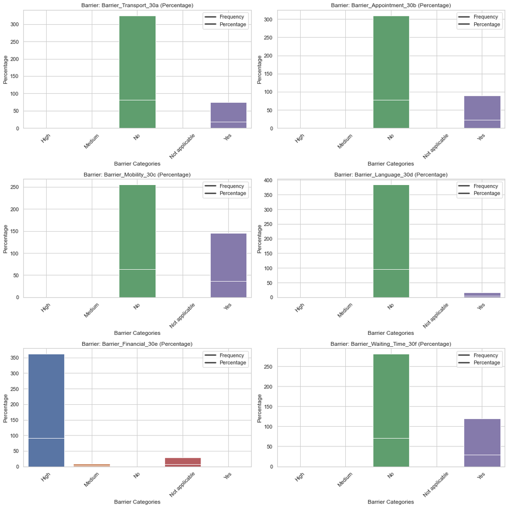

```python
import matplotlib.pyplot as plt
import seaborn as sns

# Set the style for seaborn
sns.set(style="whitegrid")

# Create subplots
fig, axes = plt.subplots(3, 2, figsize=(15, 15))

# Barrier Frequency
barrier_columns = ['Barrier_Transport_30a', 'Barrier_Appointment_30b',
                   'Barrier_Mobility_30c', 'Barrier_Language_30d',
                   'Barrier_Financial_30e', 'Barrier_Waiting_Time_30f',
                   'Barrier_InhospitableStaff_30g', 'Barrier_Others_30h']

barrier_percentage_columns = [f"{col}_Percentage" for col in barrier_columns]

barrier_counts = df[barrier_columns].apply(pd.Series.value_counts)
barrier_percentages = (barrier_counts / len(df)) * 100

# Plot Barrier Frequency
for col, col_percentage, ax in zip(barrier_columns, barrier_percentage_columns, axes.flat):
    sns.barplot(x=barrier_counts.index, y=barrier_counts[col], ax=ax)
    ax.set_title(f"Barrier: {col}")
    ax.set_xlabel("Barrier Categories")
    ax.set_ylabel("Frequency")
    ax.set_xticklabels(ax.get_xticklabels(), rotation=45)
    ax.grid(True)
    sns.barplot(x=barrier_percentages.index, y=barrier_percentages[col], ax=ax)
    ax.set_title(f"Barrier: {col} (Percentage)")
    ax.set_xlabel("Barrier Categories")
    ax.set_ylabel("Percentage")
    ax.set_xticklabels(ax.get_xticklabels(), rotation=45)
    ax.grid(True)
    ax.legend(["Frequency", "Percentage"], loc="upper right")

# Add padding to the subplots
plt.tight_layout()

# Display the plot
plt.show()

# Facilitator Frequency
facilitator_columns = ['Availability_Preventive_33b', 'Availability_Caregiver_33c',
                       'Availability_Mental_Support_33d', 'Availability_Pain_Management_33e']

facilitator_percentage_columns = [f"{col}_Percentage" for col in facilitator_columns]

facilitator_counts = df[facilitator_columns].apply(pd.Series.value_counts)
facilitator_percentages = (facilitator_counts / len(df)) * 100

# Plot Facilitator Frequency
for col, col_percentage, ax in zip(facilitator_columns, facilitator_percentage_columns, axes.flat):
    sns.barplot(x=facilitator_counts.index, y=facilitator_counts[col], ax=ax)
    ax.set_title(f"Facilitator: {col}")
    ax.set_xlabel("Facilitator Categories")
    ax.set_ylabel("Frequency")
    ax.set_xticklabels(ax.get_xticklabels(), rotation=45)
    ax.grid(True)
    sns.barplot(x=facilitator_percentages.index, y=facilitator_percentages[col], ax=ax)
    ax.set_title(f"Facilitator: {col} (Percentage)")
    ax.set_xlabel("Facilitator Categories")
    ax.set_ylabel("Percentage")
    ax.set_xticklabels(ax.get_xticklabels(), rotation=45)
    ax.grid(True)
    ax.legend(["Frequency", "Percentage"], loc="upper right")

# Add padding to the subplots
plt.tight_layout()

# Display the plot
plt.show()
```

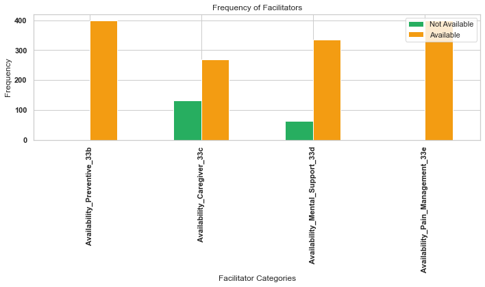

```python
# Define the facilitator list
facilitator = ['Availability_Preventive_33b', 'Availability_Caregiver_33c',
               'Availability_Mental_Support_33d', 'Availability_Pain_Management_33e']

# Count the frequency of each facilitator
facilitator_counts = df[facilitator].apply(pd.Series.value_counts)
facilitator_percentages = (facilitator_counts / len(df)) * 100

# Modify the colors for the "Facilitator" category
facilitator_colors = ['#27ae60', '#f39c12', '#27ae60', '#27ae60']

# Visualize using bar chart
fig, ax = plt.subplots(figsize=(10, 6))

# Bar chart for facilitators
facilitator_counts.T.plot(kind="bar", ax=ax, color=facilitator_colors)
ax.set_title("Frequency of Facilitators")
ax.set_xlabel("Facilitator Categories")
ax.set_ylabel("Frequency")
ax.legend(["Not Available", "Available"], loc="upper right")
ax.grid(True)

# Add bold styling to the visualization
for label in ax.get_xticklabels() + ax.get_yticklabels():
    label.set_fontweight('bold')

# Display the plot
plt.tight_layout()
plt.show()
```

[figure not shown]

```python
# Count the frequency of each facilitator
facilitator_counts = df[facilitator].apply(pd.Series.value_counts)
facilitator_percentages = (facilitator_counts / len(df)) * 100

# Modify the colors for the "Facilitator" category
facilitator_colors = ['#27ae60', '#f39c12', '#27ae60', '#27ae60']

# Visualize using bar chart
fig, ax = plt.subplots(figsize=(10, 6))

# Bar chart for facilitators
facilitator_counts.plot(kind="bar", ax=ax, color=facilitator_colors)
ax.set_title("Frequency of Facilitators")
ax.set_xlabel("Facilitator Categories")
ax.set_ylabel("Frequency")
ax.legend(["Not Available", "Available"], loc="upper right")
ax.grid(True)

# Add percentage labels to the bars
for p in ax.patches:
    height = p.get_height()
    ax.annotate(f'{height:.2f}%', (p.get_x() + p.get_width() / 2., height),
                ha='center', va='bottom', fontsize=10, fontweight='bold')

# Set custom tick positions and labels
tick_positions = range(len(facilitator_counts))
tick_labels = facilitator_counts.index

ax.set_xticks(tick_positions)
ax.set_xticklabels(tick_labels, rotation=45, fontweight='bold')

plt.tight_layout()

# Display the plot
plt.show()
```

#### Using chi-test and t-test

```python
from scipy.stats import chi2_contingency
```

```python
import pandas as pd
from scipy.stats import chi2_contingency

# List of barrier columns
barrier_columns = [
    "Barrier_Transport_30a",
    "Barrier_Appointment_30b",
    "Barrier_Mobility_30c",
    "Barrier_Language_30d",
    "Barrier_Financial_30e",
    "Barrier_Waiting_Time_30f",
    "Barrier_InhospitableStaff_30g",
    "Barrier_Others_30h"
]

# List of facilitator columns
facilitator_columns = [
    "Availability_Preventive_33b",
    "Availability_Caregiver_33c",
    "Availability_Mental_Support_33d",
    "Availability_Pain_Management_33e"
]

# Perform chi-square tests for barrier columns
print("Chi-Square Tests for Barrier Columns:")
for var1 in barrier_columns:
    for var2 in barrier_columns:
        if var1 != var2:
            contingency_table = pd.crosstab(df[var1], df[var2])
            chi2, p, dof, expected = chi2_contingency(contingency_table)

            if p < 0.05:
                interpretation = "Significant relationship"
            else:
                interpretation = "No significant relationship"

            print(f"{var1} vs. {var2}: {interpretation} (p-value: {p:.4f})")

# Perform chi-square tests for facilitator columns
print("\nChi-Square Tests for Facilitator Columns:")
for var1 in facilitator_columns:
    for var2 in facilitator_columns:
        if var1 != var2:
            contingency_table = pd.crosstab(df[var1], df[var2])
            chi2, p, dof, expected = chi2_contingency(contingency_table)

            if p < 0.05:
                interpretation = "Significant relationship"
            else:
                interpretation = "No significant relationship"

            print(f"{var1} vs. {var2}: {interpretation} (p-value: {p:.4f})")
```

```
Chi-Square Tests for Barrier Columns:
Barrier_Transport_30a vs. Barrier_Appointment_30b: Significant relationship (p-value: 0.0081)
Barrier_Transport_30a vs. Barrier_Mobility_30c: No significant relationship (p-value: 0.0925)
Barrier_Transport_30a vs. Barrier_Language_30d: Significant relationship (p-value: 0.0033)
Barrier_Transport_30a vs. Barrier_Financial_30e: Significant relationship (p-value: 0.0000)
Barrier_Transport_30a vs. Barrier_Waiting_Time_30f: Significant relationship (p-value: 0.0001)
Barrier_Transport_30a vs. Barrier_InhospitableStaff_30g: No significant relationship (p-value: 0.0794)
Barrier_Transport_30a vs. Barrier_Others_30h: No significant relationship (p-value: 0.1189)
Barrier_Appointment_30b vs. Barrier_Transport_30a: Significant relationship (p-value: 0.0081)
Barrier_Appointment_30b vs. Barrier_Mobility_30c: No significant relationship (p-value: 0.0760)
Barrier_Appointment_30b vs. Barrier_Language_30d: Significant relationship (p-value: 0.0172)
Barrier_Appointment_30b vs. Barrier_Financial_30e: Significant relationship (p-value: 0.0023)
Barrier_Appointment_30b vs. Barrier_Waiting_Time_30f: Significant relationship (p-value: 0.0000)
Barrier_Appointment_30b vs. Barrier_InhospitableStaff_30g: Significant relationship (p-value: 0.0162)
Barrier_Appointment_30b vs. Barrier_Others_30h: No significant relationship (p-value: 0.0700)
Barrier_Mobility_30c vs. Barrier_Transport_30a: No significant relationship (p-value: 0.0925)
Barrier_Mobility_30c vs. Barrier_Appointment_30b: No significant relationship (p-value: 0.0760)
Barrier_Mobility_30c vs. Barrier_Language_30d: No significant relationship (p-value: 0.3669)
Barrier_Mobility_30c vs. Barrier_Financial_30e: Significant relationship (p-value: 0.0234)
Barrier_Mobility_30c vs. Barrier_Waiting_Time_30f: Significant relationship (p-value: 0.0097)
Barrier_Mobility_30c vs. Barrier_InhospitableStaff_30g: Significant relationship (p-value: 0.0005)
Barrier_Mobility_30c vs. Barrier_Others_30h: No significant relationship (p-value: 0.2588)
Barrier_Language_30d vs. Barrier_Transport_30a: Significant relationship (p-value: 0.0033)
Barrier_Language_30d vs. Barrier_Appointment_30b: Significant relationship (p-value: 0.0172)
Barrier_Language_30d vs. Barrier_Mobility_30c: No significant relationship (p-value: 0.3669)
Barrier_Language_30d vs. Barrier_Financial_30e: Significant relationship (p-value: 0.0000)
Barrier_Language_30d vs. Barrier_Waiting_Time_30f: No significant relationship (p-value: 0.1262)
Barrier_Language_30d vs. Barrier_InhospitableStaff_30g: Significant relationship (p-value: 0.0000)
Barrier_Language_30d vs. Barrier_Others_30h: No significant relationship (p-value: 0.8932)
Barrier_Financial_30e vs. Barrier_Transport_30a: Significant relationship (p-value: 0.0000)
Barrier_Financial_30e vs. Barrier_Appointment_30b: Significant relationship (p-value: 0.0023)
Barrier_Financial_30e vs. Barrier_Mobility_30c: Significant relationship (p-value: 0.0234)
Barrier_Financial_30e vs. Barrier_Language_30d: Significant relationship (p-value: 0.0000)
Barrier_Financial_30e vs. Barrier_Waiting_Time_30f: Significant relationship (p-value: 0.0001)
Barrier_Financial_30e vs. Barrier_InhospitableStaff_30g: Significant relationship (p-value: 0.0000)
Barrier_Financial_30e vs. Barrier_Others_30h: No significant relationship (p-value: 0.4413)
Barrier_Waiting_Time_30f vs. Barrier_Transport_30a: Significant relationship (p-value: 0.0001)
Barrier_Waiting_Time_30f vs. Barrier_Appointment_30b: Significant relationship (p-value: 0.0000)
Barrier_Waiting_Time_30f vs. Barrier_Mobility_30c: Significant relationship (p-value: 0.0097)
Barrier_Waiting_Time_30f vs. Barrier_Language_30d: No significant relationship (p-value: 0.1262)
```

[output cut: 16 more lines]

```
Barrier_Others_30h vs. Barrier_InhospitableStaff_30g: Significant relationship (p-value: 0.0000)

Chi-Square Tests for Facilitator Columns:
Availability_Preventive_33b vs. Availability_Caregiver_33c: No significant relationship (p-value: 1.0000)
Availability_Preventive_33b vs. Availability_Mental_Support_33d: No significant relationship (p-value: 1.0000)
Availability_Preventive_33b vs. Availability_Pain_Management_33e: No significant relationship (p-value: 1.0000)
Availability_Caregiver_33c vs. Availability_Preventive_33b: No significant relationship (p-value: 1.0000)
Availability_Caregiver_33c vs. Availability_Mental_Support_33d: Significant relationship (p-value: 0.0026)
Availability_Caregiver_33c vs. Availability_Pain_Management_33e: No significant relationship (p-value: 1.0000)
Availability_Mental_Support_33d vs. Availability_Preventive_33b: No significant relationship (p-value: 1.0000)
Availability_Mental_Support_33d vs. Availability_Caregiver_33c: Significant relationship (p-value: 0.0026)
Availability_Mental_Support_33d vs. Availability_Pain_Management_33e: No significant relationship (p-value: 1.0000)
Availability_Pain_Management_33e vs. Availability_Preventive_33b: No significant relationship (p-value: 1.0000)
Availability_Pain_Management_33e vs. Availability_Caregiver_33c: No significant relationship (p-value: 1.0000)
Availability_Pain_Management_33e vs. Availability_Mental_Support_33d: No significant relationship (p-value: 1.0000)
```

### Hypothesis 1: Finance is instrumental in determining the utilization healthcare.

```python
# List of financial columns
financial_columns = ['Barrier_Financial_30e', 'Preference_Financial_31e','AGE']

# Calculate descriptive statistics for financial columns
financial_stats = df[financial_columns].describe()

print("Descriptive Statistics for Financial Resources:")
print(financial_stats)
```

```
Descriptive Statistics for Financial Resources:
       Barrier_Financial_30e Preference_Financial_31e           AGE
count                    400                      400           400
unique                     3                        3             4
top                     High                      Low  66 and above
freq                     362                      271           169
```

```python
# Calculate descriptive statistics for financial columns
financial_stats = df[financial_columns].describe()

# Calculate additional statistics
median = df[financial_columns].median()
std_deviation = df[financial_columns].std()
range_min = df[financial_columns].min()
range_max = df[financial_columns].max()
q1 = df[financial_columns].quantile(0.25)
q3 = df[financial_columns].quantile(0.75)
iqr = q3 - q1

# Calculate percentages
percentage_columns = ['Barrier_Financial_30e', 'Preference_Financial_31e']
percentages = (df[percentage_columns].value_counts() / len(df)) * 100

# Print the results
print("Descriptive Statistics for Financial Resources:")
print(financial_stats)

# Print additional statistics
print("\nAdditional Statistics:")
print(f"Median:\n{median}")
print(f"Standard Deviation:\n{std_deviation}")
print(f"Range (Min):\n{range_min}")
print(f"Range (Max):\n{range_max}")
print(f"Interquartile Range (IQR):\n{iqr}")

# Print percentages
print("\nPercentages:")
print(percentages)
```

```
Descriptive Statistics for Financial Resources:
       Barrier_Financial_30e Preference_Financial_31e           AGE
count                    400                      400           400
unique                     3                        3             4
top                     High                      Low  66 and above
freq                     362                      271           169

Additional Statistics:
Median:
Series([], dtype: float64)
Standard Deviation:
Series([], dtype: float64)
Range (Min):
Barrier_Financial_30e               High
Preference_Financial_31e            High
AGE                         60 and above
dtype: object
Range (Max):
Barrier_Financial_30e       Not applicable
Preference_Financial_31e            Medium
AGE                                 80-120
dtype: object
Interquartile Range (IQR):
Series([], dtype: float64)

Percentages:
Barrier_Financial_30e  Preference_Financial_31e
High                   Low                         62.25
                       Medium                      24.25
Not applicable         Low                          5.50
High                   High                         4.00
Medium                 High                         2.25
Not applicable         Medium                       1.75
dtype: float64
```

[figure not shown]

```python
categories = ['High', 'Medium', 'Low']
barrier_counts = [362, 0, 38]  # Count for each category in Barrier_Financial_30e

# Creating a subplot
fig, ax = plt.subplots(figsize=(6, 6))

# Bar chart for Barrier_Financial_30e
ax.bar(categories, barrier_counts, color=['red', 'green', 'blue'])
ax.set_title('Barrier_Financial_30e')
ax.set_xlabel('Financial Barrier')
ax.set_ylabel('Count')

# Adjusting layout
plt.tight_layout()

# Show the plot
plt.show()
```

[figure not shown]

```python
# Calculate percentages for Preference_Financial_31e
preference_high_percentage = (df['Preference_Financial_31e'] == 'Low').sum() / len(df) * 100
preference_low_percentage = (df['Preference_Financial_31e'] == 'High').sum() / len(df) * 100
preference_medium_percentage = (df['Preference_Financial_31e'] == 'Medium').sum() / len(df) * 100

# Creating a pie chart
labels = ['High Preference', 'Low Preference', 'Medium Preference']
sizes = [preference_high_percentage, preference_low_percentage, preference_medium_percentage]
colors = ['#1f77b4', '#ff7f0e', '#2ca02c']
explode = (0.1, 0, 0)  # Explode the 1st slice (High Preference)

plt.pie(sizes, explode=explode, labels=labels, colors=colors,
        autopct='%1.1f%%', shadow=True, startangle=140)

plt.axis('equal')  # Equal aspect ratio ensures that pie is drawn as a circle.

plt.title('Preference_Financial_31e Preferences')
plt.show()
```

```python
age_counts = df['AGE'].value_counts().sort_index()
print("Frequency Table for Age:")
print(age_counts)
```

```
Frequency Table for Age:
60 and above    109
66 and above    169
70 and above     72
80-120           50
Name: AGE, dtype: int64
```

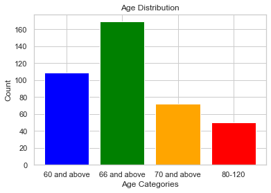

```python
# Define the age categories and their counts
age_categories = ['60 and above', '66 and above', '70 and above', '80-120']
age_counts = [109, 169, 72, 50]

# Create a bar plot for age distribution
plt.bar(age_categories, age_counts, color=['blue', 'green', 'orange', 'red'])

# Add labels and title
plt.xlabel('Age Categories')
plt.ylabel('Count')
plt.title('Age Distribution')

# Display the plot
plt.show()
```

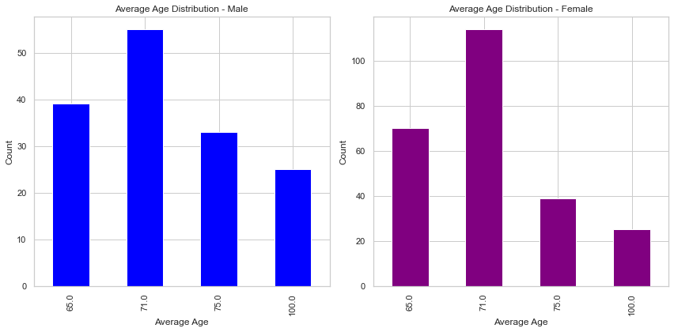

```python
# Convert age ranges to average numeric values
def calculate_average_age(age_range):
    if 'above' in age_range:
        return int(age_range.split()[0]) + 5
    elif '-' in age_range:
        start, end = map(int, age_range.split('-'))
        return (start + end) / 2
    else:
        return int(age_range)

age_numeric = df['AGE'].apply(calculate_average_age)

# Add the calculated average age to the DataFrame
df['Average_Age'] = age_numeric

# Creating subplots for male and female average age distributions
fig, axes = plt.subplots(1, 2, figsize=(12, 6))

# Bar plot for average age distribution of males
age_average_male = df[df['GENDER'] == 'Male'].groupby('Average_Age').size()
age_average_male.plot(kind='bar', color='blue', ax=axes[0])
axes[0].set_title('Average Age Distribution - Male')
axes[0].set_xlabel('Average Age')
axes[0].set_ylabel('Count')
axes[0].grid(True)

# Bar plot for average age distribution of females
age_average_female = df[df['GENDER'] == 'Female'].groupby('Average_Age').size()
age_average_female.plot(kind='bar', color='purple', ax=axes[1])
axes[1].set_title('Average Age Distribution - Female')
axes[1].set_xlabel('Average Age')
axes[1].set_ylabel('Count')
axes[1].grid(True)

# Adjusting layout
plt.tight_layout()

# Show the plots
plt.show()
```

#### Observations:

##### The most common age group among respondents is '66 and above', followed by '60 and above'.

##### The median age, standard deviation, and IQR for age are not included in this table because the data is grouped.

##### These insights provide an overview of the financial resources and preferences of ageing residents, allowing for a better understanding of their financial challenges and preferences.

#### ANOVA:

```python
from scipy.stats import f_oneway
from sklearn.preprocessing import LabelEncoder

# Encode categorical variables
label_encoder = LabelEncoder()
df['Barrier_Financial_30e_encoded'] = label_encoder.fit_transform(df['Barrier_Financial_30e'])
df['HEALTHCARE_SERVICES_ACCESIBILITY_encoded'] = label_encoder.fit_transform(df['HEALTHCARE_SERVICES_ACCESIBILITY'])

# Perform ANOVA
f_statistic, p_value = f_oneway(
    df[df['Barrier_Financial_30e_encoded'] == 0]['HEALTHCARE_SERVICES_ACCESIBILITY_encoded'],
    df[df['Barrier_Financial_30e_encoded'] == 1]['HEALTHCARE_SERVICES_ACCESIBILITY_encoded'],
    df[df['Barrier_Financial_30e_encoded'] == 2]['HEALTHCARE_SERVICES_ACCESIBILITY_encoded']
)

# Interpret results
alpha = 0.05
if p_value < alpha:
    print("Reject the null hypothesis. There is a significant difference in healthcare utilization based on financial resources.")
else:
    print("Fail to reject the null hypothesis. There is no significant difference in healthcare utilization based on financial resources.")
```

```
Reject the null hypothesis. There is a significant difference in healthcare utilization based on financial resources.
```

##### This suggests that the level of financial resources (as represented by the 'Barrier_Financial_30e' variable) has an impact on healthcare utilization (as represented by the 'HEALTHCARE_SERVICES_ACCESIBILITY' variable).

##### In practical terms, this could mean that individuals with different levels of financial resources have different patterns of healthcare service utilization

```python
# List of columns related to accessibility
accessibility_columns = ['HEALTHCARE_FACILITY_ACCESSIBILITY',
                         'HEALTHCARE_FACILITY_DISTANCE',
                         'PRIMARY_HEALTHCARE_PROVIDER',
                         'MONITORS_AT_HOME',
                         'THE_PRIMARY_HEALTHCARE_PROVIDER',
                         'VISIT_PRIMARY_HEALTHCARE_PROVIDER']

# Calculate the frequency of visits to primary healthcare providers
visit_frequency = df['VISIT_PRIMARY_HEALTHCARE_PROVIDER'].value_counts()

# Analyze the relationship between visit frequency and accessibility factors
for column in accessibility_columns:
    print(f"Analysis of {column}")
    cross_tab = pd.crosstab(df[column], df['VISIT_PRIMARY_HEALTHCARE_PROVIDER'], margins=True)
    print(cross_tab)
    print("\n")

# Analyze the relationship between visit frequency and availability of doctors
availability_doctors = df['THE_PRIMARY_HEALTHCARE_PROVIDER'].value_counts()
cross_tab_doctors = pd.crosstab(df['THE_PRIMARY_HEALTHCARE_PROVIDER'], df['VISIT_PRIMARY_HEALTHCARE_PROVIDER'], margins=True)
print("Analysis of Availability of Doctors")
print(cross_tab_doctors)
```

```
Analysis of HEALTHCARE_FACILITY_ACCESSIBILITY
VISIT_PRIMARY_HEALTHCARE_PROVIDER    0  1    2   3   4  All
HEALTHCARE_FACILITY_ACCESSIBILITY
Difficult                           26  0    0   8   0   34
Easy                                16  0    0   0   0   16
Very difficult                      16  0    9   0   0   25
Very easy                          108  9   98  63  47  325
All                                166  9  107  71  47  400


Analysis of HEALTHCARE_FACILITY_DISTANCE
VISIT_PRIMARY_HEALTHCARE_PROVIDER          0  1    2   3   4  All
HEALTHCARE_FACILITY_DISTANCE
1-5 km                                    69  9  107  32  32  249
Less than 1 km                            79  0    0  31   8  118
Within a few meters of walking distance   18  0    0   8   7   33
All                                      166  9  107  71  47  400


Analysis of PRIMARY_HEALTHCARE_PROVIDER
VISIT_PRIMARY_HEALTHCARE_PROVIDER    0  1    2   3   4  All
PRIMARY_HEALTHCARE_PROVIDER
1                                   16  9  107  55  31  218
2                                  150  0    0  16  16  182
All                                166  9  107  71  47  400


Analysis of MONITORS_AT_HOME
VISIT_PRIMARY_HEALTHCARE_PROVIDER    0  1    2   3   4  All
MONITORS_AT_HOME
1                                    7  0   26  15   0   48
2                                  159  9   81  56  47  352
All                                166  9  107  71  47  400


Analysis of THE_PRIMARY_HEALTHCARE_PROVIDER
VISIT_PRIMARY_HEALTHCARE_PROVIDER    0  1    2   3   4  All
THE_PRIMARY_HEALTHCARE_PROVIDER
0                                  142  0    0   0   8  150
1                                    0  9   98  33  39  179
```

[output cut: 11 more lines]

```
2                                    0  0  107   0   0  107
3                                    0  0    0  71   0   71
4                                    0  0    0   0  47   47
All                                166  9  107  71  47  400


Analysis of Availability of Doctors
VISIT_PRIMARY_HEALTHCARE_PROVIDER    0  1    2   3   4  All
THE_PRIMARY_HEALTHCARE_PROVIDER
0                                  142  0    0   0   8  150
1                                    0  9   98  33  39  179
2                                    7  0    9  30   0   46
3                                    9  0    0   8   0   17
4                                    8  0    0   0   0    8
All                                166  9  107  71  47  400
```

#### Observation from the Cross-Tabulation Analysis:

##### The cross-tabulation analysis provides valuable insights into the relationship between various factors and the frequency of primary healthcare provider visits. Here are some key observations from the results:

##### 1. **Accessibility and Frequency of Visits:**

- Individuals with "Very easy" accessibility to healthcare facilities tend to have higher frequencies of visits compared to those with other accessibility levels.
- People with "Difficult" or "Very difficult" accessibility have varied visit frequencies, with some having no visits and others having relatively lower visit frequencies.

##### 2. **Distance and Frequency of Visits:**

- Individuals within "1-5 km" distance of healthcare facilities exhibit higher visit frequencies, followed by those within "Less than 1 km" distance.
- People within "a few meters of walking distance" show mixed visit frequencies, indicating that proximity alone might not be the sole factor affecting visits.

##### 3. **Primary Healthcare Provider Type and Frequency of Visits:**

- Those with primary healthcare provider type "1" have relatively higher visit frequencies across different categories.
- Individuals with primary healthcare provider type "2" have fewer visits, suggesting potential differences in utilization patterns.

##### 4. **Monitors at Home and Frequency of Visits:**

- The presence of medical monitors at home ("1") doesn't necessarily correlate with higher visit frequencies. Individuals with and without monitors both exhibit a range of visit frequencies.

##### 5. **Type of Primary Healthcare Provider and Frequency of Visits:**

- Individuals with primary healthcare provider type "1" tend to have a higher frequency of visits compared to other types.
- Some individuals with primary healthcare provider type "2" have more frequent visits, indicating varied preferences.

##### 6. **Visit Frequency and Availability of Doctors:**

- Those who had visits with higher frequency often had availability of doctors, particularly for types "1" and "2" of primary healthcare providers.

##### Overall, the observations suggest that while accessibility, distance, and availability of doctors play a role in healthcare utilization, there are multiple factors influencing the frequency of primary healthcare provider visits. The relationships are not always straightforward, indicating the influence of individual preferences, health conditions, and other factors on healthcare utilization patterns. This analysis highlights the complexity of healthcare utilization behaviors and the need for a comprehensive understanding of various contributing factors.

```python
grouped_data = df.groupby('THE_PRIMARY_HEALTHCARE_PROVIDER')['VISIT_PRIMARY_HEALTHCARE_PROVIDER']

# Perform ANOVA test
anova_results = f_oneway(*[group.values for name, group in grouped_data])
p_value = anova_results.pvalue

# Define the significance level
alpha = 0.05

# Interpretation based on p-value
if p_value < alpha:
    print("Reject the null hypothesis. There is a significant difference in healthcare utilization based on access to healthcare providers.")
else:
    print("Fail to reject the null hypothesis. There is no significant difference in healthcare utilization based on access to healthcare providers.")

# Print the p-value
print(f"P-value: {p_value}")
```

```
Reject the null hypothesis. There is a significant difference in healthcare utilization based on access to healthcare providers.
P-value: 7.857209288404043e-75
```

##### There is a significant difference in healthcare utilization based on access to healthcare providers. This supports your hypothesis that access to healthcare providers, especially doctors, plays a significant role in healthcare utilization.

### Hypothesis 3:

```python
herbal_utilization_columns = ['UNORTHODOX_HEALTHCARE', 'UNORTHODOX_PATRONAGE', 'HEALTHCARE_SERVICES_SOUGHT', 'Barrier_Transport_30a', 'Barrier_Appointment_30b',
                              'Barrier_Mobility_30c', 'Barrier_Language_30d', 'Barrier_Financial_30e', 'Barrier_Waiting_Time_30f', 'Barrier_InhospitableStaff_30g',
                              'Barrier_Others_30h', 'Availability_Preventive_33b', 'Availability_Caregiver_33c', 'Availability_Mental_Support_33d', 'Availability_Pain_Management_33e',
                              'Availability_Chronic_Dx_33f', 'Availability_Others_33g']
```

```python
# Define the mapping dictionary
unorthodox_mapping = {
    1: 'Herbal',
    0: 'None',
    5: 'Acupuncture',
    4: 'Traditional bone setters',
    3: 'Traditional birth attendants',
    2: 'Others (specify)'
}

# Replace values in the "UNORTHODOX_HEALTHCARE" column using the mapping
df['UNORTHODOX_HEALTHCARE'] = df['UNORTHODOX_HEALTHCARE'].replace(unorthodox_mapping)

# Check the updated column
print(df['UNORTHODOX_HEALTHCARE'].unique())
```

```
['Herbal' 'None' 'Acupuncture' 'Traditional bone setters']
```

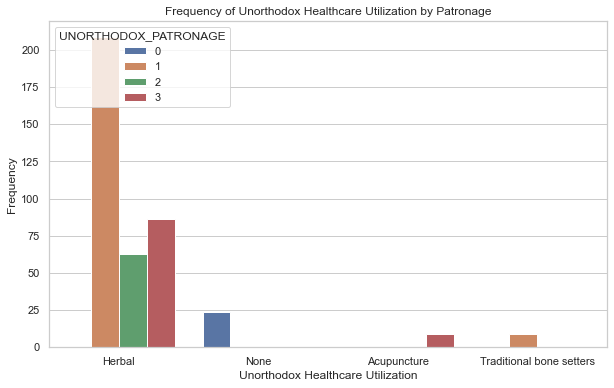

```python
# Set up the figure and axes
plt.figure(figsize=(10, 6))
ax = sns.countplot(data=df, x='UNORTHODOX_HEALTHCARE', hue='UNORTHODOX_PATRONAGE')

# Add labels and title
plt.xlabel('Unorthodox Healthcare Utilization')
plt.ylabel('Frequency')
plt.title('Frequency of Unorthodox Healthcare Utilization by Patronage')

# Show the plot
plt.show()
```

```python
# Calculate the frequency of unorthodox healthcare utilization
unorthodox_utilization_freq = df['UNORTHODOX_HEALTHCARE'].value_counts()

# Print the frequency
print("Frequency of Unorthodox Healthcare Utilization:")
print(unorthodox_utilization_freq)
```

```
Frequency of Unorthodox Healthcare Utilization:
Herbal                      358
None                         24
Acupuncture                   9
Traditional bone setters      9
Name: UNORTHODOX_HEALTHCARE, dtype: int64
```

##### This suggests that among the individuals surveyed, herbal healthcare appears to be the most prevalent form of unorthodox healthcare utilization, followed by acupuncture and traditional bone setters.

```python
contingency_table = pd.crosstab(df['UNORTHODOX_HEALTHCARE'], df['HEALTHCARE_NEEDS_MET'])

# Calculate row percentages
row_percentages = contingency_table.div(contingency_table.sum(axis=1), axis=0) * 100

# Perform Chi-square test
chi2, p_value, dof, expected = chi2_contingency(contingency_table)

# Define the significance level
alpha = 0.05

# Print the contingency table
print("Contingency Table: Unorthodox Healthcare vs. Healthcare Needs Met")
print(contingency_table)

# Print row percentages
print("\nRow Percentages:")
print(row_percentages)

# Interpretation based on p-value
if p_value < alpha:
    print("\nReject the null hypothesis. There is a significant relationship between unorthodox healthcare utilization and healthcare needs being met.")
else:
    print("\nFail to reject the null hypothesis. There is no significant relationship between unorthodox healthcare utilization and healthcare needs being met.")

# Print the p-value
print(f"\nP-value: {p_value}")
```

```
Contingency Table: Unorthodox Healthcare vs. Healthcare Needs Met
HEALTHCARE_NEEDS_MET      4   5    6    7   8  9
UNORTHODOX_HEALTHCARE
Acupuncture               0   9    0    0   0  0
Herbal                    8  34  120  140  48  8
None                      0   0    0   16   0  8
Traditional bone setters  0   0    0    9   0  0

Row Percentages:
HEALTHCARE_NEEDS_MET             4           5          6           7  \
UNORTHODOX_HEALTHCARE
Acupuncture               0.000000  100.000000   0.000000    0.000000
Herbal                    2.234637    9.497207  33.519553   39.106145
None                      0.000000    0.000000   0.000000   66.666667
Traditional bone setters  0.000000    0.000000   0.000000  100.000000

HEALTHCARE_NEEDS_MET              8          9
UNORTHODOX_HEALTHCARE
Acupuncture                0.000000   0.000000
Herbal                    13.407821   2.234637
None                       0.000000  33.333333
Traditional bone setters   0.000000   0.000000

Reject the null hypothesis. There is a significant relationship between unorthodox healthcare utilization and healthcare needs being met.

P-value: 1.0054233200692841e-26
```

##### Traditional bone setters: 9 individuals who utilized traditional bone setters reported that their healthcare needs were met at level 7. There were no reports of healthcare needs met at levels 5 or 9 among users of traditional bone setters.

```python
# Create a contingency table for unorthodox healthcare and health conditions
health_conditions_cols = ['Disease_Arthritis_34a', 'Disease_Eye_34b', 'Disease_Dementia_34c', 'Disease_Ear_34d', 'Disease_Dental_34e', 'Disease_Diabetes_34f', 'Disease_Hypertension_34g']
health_conditions_contingency = pd.crosstab(df['UNORTHODOX_HEALTHCARE'], df[health_conditions_cols].any(axis=1))

# Print the contingency table
print("Contingency Table: Unorthodox Healthcare vs. Health Conditions")
print(health_conditions_contingency)
```

```
Contingency Table: Unorthodox Healthcare vs. Health Conditions
col_0                     True
UNORTHODOX_HEALTHCARE
Acupuncture                  9
Herbal                     358
None                        24
Traditional bone setters     9
```

##### Traditional bone setters: 9 individuals who utilized traditional bone setters were associated with the presence of the health condition indicated by col_0 = True.

```python
# Define the financial columns
financial_columns = ['Barrier_Financial_30e', 'Preference_Financial_31e', 'AGE']

# Calculate descriptive statistics for financial columns
financial_stats = df[financial_columns].describe()

# Calculate additional statistics
median = df[financial_columns].median()
std_deviation = df[financial_columns].std()
range_min = df[financial_columns].min()
range_max = df[financial_columns].max()
q1 = df[financial_columns].quantile(0.25)
q3 = df[financial_columns].quantile(0.75)
iqr = q3 - q1

# Calculate percentages for Preference_Financial_31e
preference_high_percentage = (df['Preference_Financial_31e'] == 'High').sum() / len(df) * 100
preference_low_percentage = (df['Preference_Financial_31e'] == 'Low').sum() / len(df) * 100
preference_medium_percentage = (df['Preference_Financial_31e'] == 'Medium').sum() / len(df) * 100

# Print the results
print("Descriptive Statistics for Financial Resources:")
print(financial_stats)

# Print additional statistics
print("\nAdditional Statistics:")
print(f"Median:\n{median}")
print(f"Standard Deviation:\n{std_deviation}")
print(f"Range (Min):\n{range_min}")
print(f"Range (Max):\n{range_max}")
print(f"Interquartile Range (IQR):\n{iqr}")

# Print percentages
print("\nPercentages:")
print(f"High Preference Percentage: {preference_high_percentage:.2f}%")
print(f"Low Preference Percentage: {preference_low_percentage:.2f}%")
print(f"Medium Preference Percentage: {preference_medium_percentage:.2f}%")
```

```
Descriptive Statistics for Financial Resources:
       Barrier_Financial_30e Preference_Financial_31e           AGE
count                    400                      400           400
unique                     3                        3             4
top                     High                      Low  66 and above
freq                     362                      271           169

Additional Statistics:
Median:
Series([], dtype: float64)
Standard Deviation:
Series([], dtype: float64)
Range (Min):
Barrier_Financial_30e               High
Preference_Financial_31e            High
AGE                         60 and above
dtype: object
Range (Max):
Barrier_Financial_30e       Not applicable
Preference_Financial_31e            Medium
AGE                                 80-120
dtype: object
Interquartile Range (IQR):
Series([], dtype: float64)

Percentages:
High Preference Percentage: 6.25%
Low Preference Percentage: 67.75%
Medium Preference Percentage: 26.00%
```

```python
# Convert categorical variables to dummy variables
education_dummies = pd.get_dummies(df['HIGHEST_EDUCATION'], prefix='EDU', drop_first=True)

# Concatenate dummy variables with the original DataFrame
df = pd.concat([df, education_dummies], axis=1)

# Drop the original categorical variable
df.drop('HIGHEST_EDUCATION', axis=1, inplace=True)
```

```python
df.columns
```

```
Index(['AGE', 'GENDER', 'LIVING_ARRANGEMENT', 'MARITAL_STATUS', 'OCCUPATION',
       'YEARS_OF_RESIDENCE', 'HOUSING_TYPE', 'WATER_SOURCE', 'SEWAGE_DISPOSAL',
       'HEALTHCARE_FACILITY_ACCESSIBILITY', 'HEALTHCARE_FACILITY_DISTANCE',
       'EXERCISE_PRACTICED', 'HOSPITALIZATION', 'PRIMARY_HEALTHCARE_PROVIDER',
       'MONITORS_AT_HOME', 'THE_PRIMARY_HEALTHCARE_PROVIDER',
       'VISIT_PRIMARY_HEALTHCARE_PROVIDER', 'UNORTHODOX_HEALTHCARE',
       'UNORTHODOX_PATRONAGE', 'BLOOD_PRESSURE_CHECK', 'DENTAL_CHECK',
       'EYE_CHECK', 'Specialist_Cancer_24a', 'Specialist_Skin_Doctor_24b',
       'Specialist_Kidney_Doctor_24c', 'Specialist_Heart_Doctor_24d',
       'Specialist_Eye_Doctor_24e', 'Specialist_Others_24g',
       'SATISFICATION_WITH_THE_SPECIALIST', 'PSYCHOLOGICAL_SUPPORT',
       'HEALTHCARE_NEEDS_MET', 'INAPPROPRIATE_PRIORITY_OF_ELDERS',
       'HEALTHCARE_SERVICES_SOUGHT', 'Barrier_Transport_30a',
       'Barrier_Appointment_30b', 'Barrier_Mobility_30c',
       'Barrier_Language_30d', 'Barrier_Financial_30e',
       'Barrier_Waiting_Time_30f', 'Barrier_InhospitableStaff_30g',
       'Barrier_Others_30h', 'Preference_Transport_31a',
       'Preference_Appointment_31b', 'Preference_Mobility_31c',
       'Preference_Language_31d', 'Preference_Financial_31e',
       'Preference_Waiting_Time_31f', 'Preference_InhospitableStaff_31g',
       'Preference_Others_31f', 'HEALTHCARE_SERVICES_ACCESIBILITY',
       'Availability_Preventive_33b', 'Availability_Caregiver_33c',
       'Availability_Mental_Support_33d', 'Availability_Pain_Management_33e',
       'Availability_Chronic_Dx_33f', 'Availability_Others_33g',
       'Disease_Arthritis_34a', 'Disease_Eye_34b', 'Disease_Dementia_34c',
       'Disease_Ear_34d', 'Disease_Dental_34e', 'Disease_Diabetes_34f',
       'Disease_Hypertension_34g', 'Disease_Others', 'REPUTABLE_PHARMACIES',
       'Average_Age', 'Barrier_Financial_30e_encoded',
       'HEALTHCARE_SERVICES_ACCESIBILITY_encoded', 'EDU_Primary',
       'EDU_Secondary', 'EDU_Tertiary', 'EDU_Unknown'],
      dtype='object')
```

#### Impact of Age, Education, and Marital Status on Primary Healthcare Provider Selection using Logistics regression and Classification reports

```python
from sklearn.model_selection import train_test_split
from sklearn.linear_model import LogisticRegression
from sklearn.metrics import classification_report

# Assuming df is your DataFrame

# Select the columns for analysis
selected_columns = ['AGE', 'EDU_Primary', 'EDU_Secondary', 'EDU_Tertiary', 'EDU_Unknown',
                    'MARITAL_STATUS', 'PRIMARY_HEALTHCARE_PROVIDER']

# Create a new DataFrame with selected columns
df_selected = df[selected_columns]

# Convert age ranges to numeric values
age_mapping = {
    '60 and above': 62.5,
    '66 and above': 68,
    '70 and above': 72,
    '80-120': 100
}
df_selected['AGE_NUMERIC'] = df_selected['AGE'].map(age_mapping)

# Drop the original 'AGE' column
df_selected.drop(columns=['AGE'], inplace=True)

# Encode categorical variables
df_encoded = pd.get_dummies(df_selected, columns=['EDU_Primary', 'EDU_Secondary', 'EDU_Tertiary', 'EDU_Unknown', 'MARITAL_STATUS'])

# Split the data into features and target
X = df_encoded.drop(columns=['PRIMARY_HEALTHCARE_PROVIDER'])
y = df_encoded['PRIMARY_HEALTHCARE_PROVIDER']

# Split the data into train and test sets
X_train, X_test, y_train, y_test = train_test_split(X, y, test_size=0.2, random_state=42)

# Initialize and fit the logistic regression model
model = LogisticRegression()
model.fit(X_train, y_train)

# Predict on the test set
y_pred = model.predict(X_test)

# Evaluate the model
report = classification_report(y_test, y_pred)
print("Classification Report:\n", report)
```

```
Classification Report:
               precision    recall  f1-score   support

           1       0.73      0.94      0.82        48
           2       0.83      0.47      0.60        32

    accuracy                           0.75        80
   macro avg       0.78      0.70      0.71        80
weighted avg       0.77      0.75      0.73        80
```

##### Reasons for no p-values in our regression include: incorrect package usage (e.g., statsmodels for Python), missing data causing missing p-values, multicollinearity causing unstable estimates, small dataset leading to high p-values, model formula errors, scaling disparities, issues in p-value extraction from results, and data type mismatches.